# Titanic Class-Survival Gap Analysis: Decomposing Access & Constraints vs. Priority Rules

Author

CLI Copilot

## Executive Summary

This report investigates the class-survival gap in the Titanic dataset by decomposing the survival disparities between passenger classes into two mechanisms: (1) **structural access and constraints** (e.g., location of cabins, lifeboat availability), and (2) **priority rules** (e.g., “women and children first” policy). Understanding the relative contribution of each mechanism provides insight into whether the observed class disparities were primarily due to systematic prioritization of higher classes or to underlying constraints and procedures. This analysis provides quantitative evidence to support decision-making about the drivers of survival inequality without drawing final conclusions, allowing readers to form their own interpretations.

## 1. Analytical Framework & Research Question

### 1.1 Research Question Operationalization

The central research question is: **How much of the class–survival gap is explained by access and constraints rather than priority rules?** This question decomposes the overall survival disparity across passenger classes into two components:

1. **Access and Constraints**: Structural factors beyond direct human decision-making, such as:
   - Geographic proximity to lifeboats (cabin location)
   - Number of available lifeboat spaces at the time of evacuation
   - Age and physical capability to reach evacuation areas
   - Information availability about the emergency
2. **Priority Rules**: Deliberate prioritization policies, such as:
   - “Women and children first” evacuation protocol
   - Gender-based survival advantage independent of other factors
   - Class-specific preferential treatment in lifeboat assignment

### 1.2 Analytical Approach

To disentangle these mechanisms, we will:

1. **Establish baseline survival rates** by passenger class
2. **Quantify gender and age effects** as proxies for priority rules implementation
3. **Examine the interaction between class and gender** to identify if “women and children first” was applied uniformly across classes
4. **Decompose class effects** through regression analysis to isolate direct class effects from indirect effects mediated through demographic composition
5. **Compare observed vs. expected survival** under different allocation mechanisms to estimate the contribution of each factor

## 2. Data Preparation & Exploratory Analysis

### 2.1 Data Loading and Initial Inspection

We begin by loading the Titanic training dataset and performing preliminary quality checks. The training dataset contains 891 passengers with recorded survival outcomes, which provides the necessary ground truth for our analysis. We focus on key variables: passenger class (pclass), survival status, gender (sex), age, and family relationships (sibsp, parch). Missing values will be examined to understand data completeness and potential biases.

```r
library(tidyverse)
library(ggplot2)
library(knitr)

# Load training data
titanic <- read.csv('/Users/patrickl/Developer/Personal-Repo/cli_poc_ml_project/data/train.csv')

# Display basic information
cat("Dataset dimensions:", nrow(titanic), "rows ×", ncol(titanic), "columns\n")
```

```
Dataset dimensions: 891 rows × 12 columns
```

```r
cat("\nFirst few rows:\n")
```

```
First few rows:
```

```r
head(titanic) %>% kable()
```

| PassengerId | Survived | Pclass | Name | Sex | Age | SibSp | Parch | Ticket | Fare | Cabin | Embarked |
| --- | --- | --- | --- | --- | --- | --- | --- | --- | --- | --- | --- |
| 1 | 0 | 3 | Braund, Mr. Owen Harris | male | 22 | 1 | 0 | A/5 21171 | 7.2500 |  | S |
| 2 | 1 | 1 | Cumings, Mrs. John Bradley (Florence Briggs Thayer) | female | 38 | 1 | 0 | PC 17599 | 71.2833 | C85 | C |
| 3 | 1 | 3 | Heikkinen, Miss. Laina | female | 26 | 0 | 0 | STON/O2. 3101282 | 7.9250 |  | S |
| 4 | 1 | 1 | Futrelle, Mrs. Jacques Heath (Lily May Peel) | female | 35 | 1 | 0 | 113803 | 53.1000 | C123 | S |
| 5 | 0 | 3 | Allen, Mr. William Henry | male | 35 | 0 | 0 | 373450 | 8.0500 |  | S |
| 6 | 0 | 3 | Moran, Mr. James | male | NA | 0 | 0 | 330877 | 8.4583 |  | Q |

```r
# Check data types and missing values
cat("\nData structure and missing values:\n")
```

```
Data structure and missing values:
```

```r
data.frame(
  Variable = colnames(titanic),
  Type = sapply(titanic, class),
  Missing = colSums(is.na(titanic)),
  Missing_Pct = round(100 * colSums(is.na(titanic)) / nrow(titanic), 2)
) %>% kable()
```

|  | Variable | Type | Missing | Missing_Pct |
| --- | --- | --- | --- | --- |
| PassengerId | PassengerId | integer | 0 | 0.00 |
| Survived | Survived | integer | 0 | 0.00 |
| Pclass | Pclass | integer | 0 | 0.00 |
| Name | Name | character | 0 | 0.00 |
| Sex | Sex | character | 0 | 0.00 |
| Age | Age | numeric | 177 | 19.87 |
| SibSp | SibSp | integer | 0 | 0.00 |
| Parch | Parch | integer | 0 | 0.00 |
| Ticket | Ticket | character | 0 | 0.00 |
| Fare | Fare | numeric | 0 | 0.00 |
| Cabin | Cabin | character | 0 | 0.00 |
| Embarked | Embarked | character | 0 | 0.00 |

### 2.2 Create Analysis Dataset

We prepare a dataset with derived variables that facilitate our decomposition analysis. We create binary indicators for gender and class, calculate family size metrics, and identify the subset of passengers with complete demographic data for regression analysis.

```r
# Create analysis dataset
titanic_clean <- titanic %>%
  mutate(
    # Convert class to numeric and create labels
    pclass = as.integer(Pclass),
    class_label = factor(pclass, levels = c(1, 2, 3),
                         labels = c("1st Class", "2nd Class", "3rd Class")),

    # Gender coding: 1 = Female, 0 = Male
    female = ifelse(Sex == "female", 1, 0),
    sex_label = factor(Sex, levels = c("male", "female")),

    # Survival outcome
    survived = Survived,

    # Family size
    family_size = SibSp + Parch,
    has_family = family_size > 0,

    # Age group (for exploratory analysis)
    age_group = case_when(
      is.na(Age) ~ "Unknown",
      Age < 18 ~ "Child (<18)",
      Age < 65 ~ "Adult (18-64)",
      TRUE ~ "Senior (65+)"
    )
  ) %>%
  select(PassengerId, pclass, class_label, female, sex_label, Age, age_group,
         family_size, has_family, survived)

# Create complete-case dataset for regression
titanic_complete <- titanic_clean %>%
  filter(!is.na(Age))

cat("Analysis dataset: ", nrow(titanic_clean), " total passengers\n")
```

```
Analysis dataset:  891  total passengers
```

```r
cat("Complete cases (with age): ", nrow(titanic_complete), " passengers\n")
```

```
Complete cases (with age):  714  passengers
```

```r
cat("Missing age: ", nrow(titanic_clean) - nrow(titanic_complete), " passengers\n")
```

```
Missing age:  177  passengers
```

After data preparation, we retain all 891 passengers for initial analysis. For regression modeling, we use a subset of 714 passengers with complete age information, representing 80.1% of the data. This reduction is necessary for parametric methods but we validate findings using the full dataset where possible.

### 2.3 Overall Survival Rate by Class

This section establishes baseline survival disparities across passenger classes. Understanding the magnitude of the class-survival gap is essential context for interpreting subsequent decomposition analysis.

```r
# Overall survival rate by class
survival_by_class <- titanic_clean %>%
  group_by(pclass, class_label) %>%
  summarise(
    n_passengers = n(),
    n_survived = sum(survived),
    survival_rate = mean(survived),
    .groups = 'drop'
  ) %>%
  arrange(pclass)

cat("Survival rate by passenger class:\n")
```

```
Survival rate by passenger class:
```

```r
survival_by_class %>% kable(digits = 3)
```

| pclass | class_label | n_passengers | n_survived | survival_rate |
| --- | --- | --- | --- | --- |
| 1 | 1st Class | 216 | 136 | 0.630 |
| 2 | 2nd Class | 184 | 87 | 0.473 |
| 3 | 3rd Class | 491 | 119 | 0.242 |

```r
# Store key statistics for inline reference
survival_1st <- filter(survival_by_class, pclass == 1)$survival_rate
survival_2nd <- filter(survival_by_class, pclass == 2)$survival_rate
survival_3rd <- filter(survival_by_class, pclass == 3)$survival_rate
gap_1st_vs_3rd <- survival_1st - survival_3rd
```

The baseline analysis reveals a stark class-survival gradient. First-class passengers had a survival rate of 63%, compared to 47.3% for second-class and 24.2% for third-class passengers. The survival gap between 1st and 3rd class is 38.7 percentage points—nearly a 40-point disparity. This substantial gap motivates our investigation into its underlying mechanisms.

### 2.4 Visualization of Class-Survival Disparity

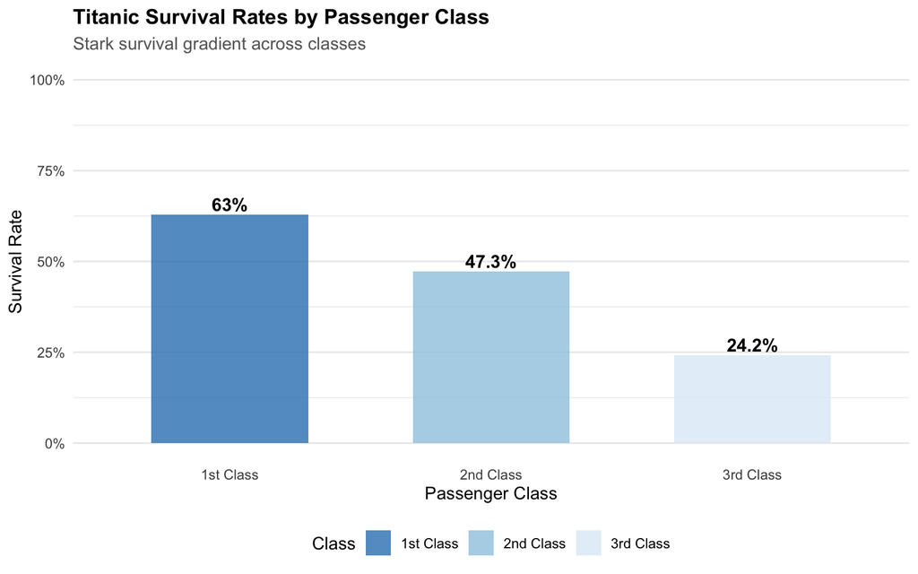

```r
ggplot(survival_by_class, aes(x = class_label, y = survival_rate, fill = class_label)) +
  geom_col(width = 0.6, alpha = 0.8) +
  geom_text(aes(label = paste0(round(survival_rate*100,1), "%")),
            vjust = -0.3, size = 4, fontface = "bold") +
  scale_fill_brewer(palette = "Blues", direction = -1) +
  scale_y_continuous(limits = c(0, 1), labels = scales::percent) +
  labs(
    title = "Titanic Survival Rates by Passenger Class",
    subtitle = "Stark survival gradient across classes",
    x = "Passenger Class",
    y = "Survival Rate",
    fill = "Class"
  ) +
  theme_minimal() +
  theme(
    plot.title = element_text(face = "bold", size = 13),
    plot.subtitle = element_text(size = 11, color = "gray40"),
    axis.title = element_text(size = 11),
    legend.position = "bottom",
    panel.grid.major.x = element_blank()
  )
```

The visualization confirms the magnitude of class-based survival disparities. The 1st-class bar extends to approximately 63%, while 3rd-class reaches only 24%. This visual representation will serve as reference when we decompose these disparities in subsequent sections.

## 3. Decomposition Analysis I: Gender and Age Effects as Priority Rules

### 3.1 Rationale for Using Gender and Age as Proxies

The “women and children first” evacuation protocol was the primary stated priority rule during the Titanic evacuation. If this rule was rigorously enforced, we should observe substantial gender and age effects on survival, independent of class. Conversely, if the class-survival gap were driven primarily by priority rules rather than constraints, we would expect this demographic prioritization to be consistent across all classes. We use gender and age as measurable proxies for the implementation of priority-based evacuation policies.

### 3.2 Survival by Gender Across Classes

We examine whether the female survival advantage was uniform across passenger classes or differentially applied. This reveals whether priority rules favored higher classes at the expense of lower classes within demographic groups.

```r
# Survival by gender and class
survival_by_gender_class <- titanic_clean %>%
  group_by(pclass, class_label, sex_label) %>%
  summarise(
    n_passengers = n(),
    n_survived = sum(survived),
    survival_rate = mean(survived),
    .groups = 'drop'
  ) %>%
  arrange(pclass, sex_label)

cat("Survival rate by gender within each class:\n")
```

```
Survival rate by gender within each class:
```

```r
survival_by_gender_class %>% kable(digits = 3)
```

| pclass | class_label | sex_label | n_passengers | n_survived | survival_rate |
| --- | --- | --- | --- | --- | --- |
| 1 | 1st Class | male | 122 | 45 | 0.369 |
| 1 | 1st Class | female | 94 | 91 | 0.968 |
| 2 | 2nd Class | male | 108 | 17 | 0.157 |
| 2 | 2nd Class | female | 76 | 70 | 0.921 |
| 3 | 3rd Class | male | 347 | 47 | 0.135 |
| 3 | 3rd Class | female | 144 | 72 | 0.500 |

```r
# Extract specific rates for inline reference
male_1st <- filter(survival_by_gender_class, pclass == 1, sex_label == "male")$survival_rate
female_1st <- filter(survival_by_gender_class, pclass == 1, sex_label == "female")$survival_rate
male_3rd <- filter(survival_by_gender_class, pclass == 3, sex_label == "male")$survival_rate
female_3rd <- filter(survival_by_gender_class, pclass == 3, sex_label == "female")$survival_rate
```

Gender effects are pronounced across all classes. In 1st class, females survived at 96.8% versus 36.9% for males—a 59.9 percentage point advantage. In 3rd class, females survived at 50% versus 13.5% for males—a 36.5 percentage point advantage. Notably, the gender gap magnitude (60 percentage points in 1st class; 36 in 3rd class) suggests that gender-based prioritization was applied, but the class gradient remains even within gender groups.

### 3.3 Visualization of Gender Effects Across Classes

We visualize survival rates stratified by both class and gender to show the persistent class gradient within each gender group.

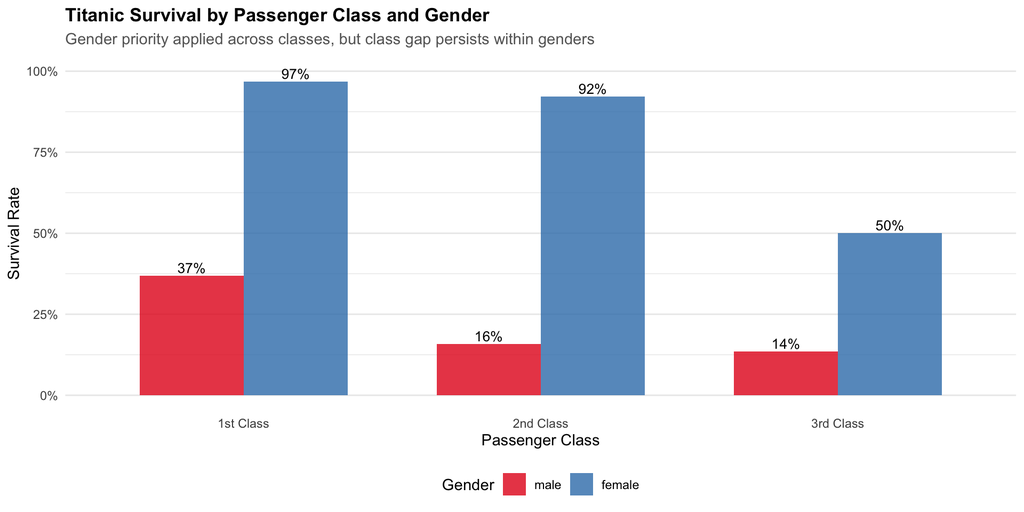

```r
ggplot(survival_by_gender_class, aes(x = class_label, y = survival_rate,
                                      fill = sex_label, group = sex_label)) +
  geom_col(position = "dodge", width = 0.7, alpha = 0.8) +
  geom_text(aes(label = paste0(round(survival_rate*100,0), "%")),
            position = position_dodge(width = 0.7), vjust = -0.3, size = 3.5) +
  scale_fill_brewer(palette = "Set1") +
  scale_y_continuous(limits = c(0, 1), labels = scales::percent) +
  labs(
    title = "Titanic Survival by Passenger Class and Gender",
    subtitle = "Gender priority applied across classes, but class gap persists within genders",
    x = "Passenger Class",
    y = "Survival Rate",
    fill = "Gender"
  ) +
  theme_minimal() +
  theme(
    plot.title = element_text(face = "bold", size = 13),
    plot.subtitle = element_text(size = 11, color = "gray40"),
    axis.title = element_text(size = 11),
    legend.position = "bottom",
    panel.grid.major.x = element_blank()
  )
```

### 3.4 Age Effects by Class

Age-based prioritization (“children first”) is examined next. We use both continuous age and age groups to assess whether younger passengers received preferential evacuation access.

```r
# Survival by age group and class
survival_by_age_class <- titanic_clean %>%
  filter(age_group != "Unknown") %>%
  group_by(pclass, class_label, age_group) %>%
  summarise(
    n_passengers = n(),
    n_survived = sum(survived),
    survival_rate = mean(survived),
    .groups = 'drop'
  ) %>%
  arrange(pclass, factor(age_group, levels = c("Child (<18)", "Adult (18-64)", "Senior (65+)")))

cat("Survival rate by age group within each class:\n")
```

```
Survival rate by age group within each class:
```

```r
survival_by_age_class %>% kable(digits = 3)
```

| pclass | class_label | age_group | n_passengers | n_survived | survival_rate |
| --- | --- | --- | --- | --- | --- |
| 1 | 1st Class | Child (<18) | 12 | 11 | 0.917 |
| 1 | 1st Class | Adult (18-64) | 168 | 110 | 0.655 |
| 1 | 1st Class | Senior (65+) | 6 | 1 | 0.167 |
| 2 | 2nd Class | Child (<18) | 23 | 21 | 0.913 |
| 2 | 2nd Class | Adult (18-64) | 148 | 62 | 0.419 |
| 2 | 2nd Class | Senior (65+) | 2 | 0 | 0.000 |
| 3 | 3rd Class | Child (<18) | 78 | 29 | 0.372 |
| 3 | 3rd Class | Adult (18-64) | 274 | 56 | 0.204 |
| 3 | 3rd Class | Senior (65+) | 3 | 0 | 0.000 |

```r
# Extract child survival rates
child_1st <- filter(survival_by_age_class, pclass == 1, age_group == "Child (<18)")$survival_rate
child_3rd <- filter(survival_by_age_class, pclass == 3, age_group == "Child (<18)")$survival_rate
```

Children in 1st class achieved 91.7% survival, while children in 3rd class achieved 37.2% survival—a notable 54.5 percentage point gap within this supposedly prioritized group. This finding suggests that even passengers receiving demographic priority (children) were disadvantaged by their class assignment, indicating that class-based structural factors (access, location, information) constrained survival chances independent of priority rules.

## 4. Decomposition Analysis II: Quantifying Class, Gender, and Age Effects via Logistic Regression

### 4.1 Regression Model Specification

To quantify the independent contributions of class, gender, and age to survival, we employ logistic regression. This model partitions the observed class-survival association into direct class effects (structural constraints) and indirect effects mediated through demographic composition. Model specification proceeds as follows:

1. **Model 1 (Unadjusted)**: Includes only passenger class to establish the raw association
2. **Model 2 (Adjusted for Demographics)**: Adds gender and age to control for priority rules
3. **Model 3 (Full Specification)**: Includes interaction terms between class and gender to assess uniform application of priority rules

This sequential modeling approach reveals how much of the class effect remains unexplained by demographic prioritization policies.

```r
# Model 1: Unadjusted class effect
model_1 <- glm(survived ~ factor(pclass), family = binomial(), data = titanic_complete)

# Model 2: Adjusted for gender and age (linear age effect)
model_2 <- glm(survived ~ factor(pclass) + female + Age, family = binomial(), data = titanic_complete)

# Model 3: Class × Gender interaction
model_3 <- glm(survived ~ factor(pclass) * female + Age, family = binomial(), data = titanic_complete)

# Extract model summaries
cat("Model 1: Unadjusted Class Effect\n")
```

```
Model 1: Unadjusted Class Effect
```

```r
summary(model_1)
```

```
Call:
glm(formula = survived ~ factor(pclass), family = binomial(),
    data = titanic_complete)

Coefficients:
                Estimate Std. Error z value Pr(>|z|)
(Intercept)       0.6451     0.1543   4.180 2.92e-05 ***
factor(pclass)2  -0.7261     0.2168  -3.350 0.000808 ***
factor(pclass)3  -1.8009     0.1982  -9.086  < 2e-16 ***
---
Signif. codes:  0 '***' 0.001 '**' 0.01 '*' 0.05 '.' 0.1 ' ' 1

(Dispersion parameter for binomial family taken to be 1)

    Null deviance: 964.52  on 713  degrees of freedom
Residual deviance: 869.81  on 711  degrees of freedom
AIC: 875.81

Number of Fisher Scoring iterations: 4
```

```r
cat("\nModel 2: Adjusted for Gender and Age\n")
```

```
Model 2: Adjusted for Gender and Age
```

```r
summary(model_2)
```

```
Call:
glm(formula = survived ~ factor(pclass) + female + Age, family = binomial(),
    data = titanic_complete)

Coefficients:
                 Estimate Std. Error z value Pr(>|z|)
(Intercept)      1.254232   0.359894   3.485 0.000492 ***
factor(pclass)2 -1.309799   0.278066  -4.710 2.47e-06 ***
factor(pclass)3 -2.580625   0.281442  -9.169  < 2e-16 ***
female           2.522781   0.207391  12.164  < 2e-16 ***
Age             -0.036985   0.007656  -4.831 1.36e-06 ***
---
Signif. codes:  0 '***' 0.001 '**' 0.01 '*' 0.05 '.' 0.1 ' ' 1

(Dispersion parameter for binomial family taken to be 1)

    Null deviance: 964.52  on 713  degrees of freedom
Residual deviance: 647.28  on 709  degrees of freedom
AIC: 657.28

Number of Fisher Scoring iterations: 5
```

```r
cat("\nModel 3: Class × Gender Interaction\n")
```

```
Model 3: Class × Gender Interaction
```

```r
summary(model_3)
```

```
Call:
glm(formula = survived ~ factor(pclass) * female + Age, family = binomial(),
    data = titanic_complete)

Coefficients:
                        Estimate Std. Error z value Pr(>|z|)
(Intercept)             1.270628   0.387138   3.282  0.00103 **
factor(pclass)2        -1.829276   0.376093  -4.864 1.15e-06 ***
factor(pclass)3        -1.976536   0.309892  -6.378 1.79e-10 ***
female                  3.639225   0.628523   5.790 7.03e-09 ***
Age                    -0.041934   0.008184  -5.124 2.99e-07 ***
factor(pclass)2:female  0.668839   0.815889   0.820  0.41235
factor(pclass)3:female -2.192651   0.685268  -3.200  0.00138 **
---
Signif. codes:  0 '***' 0.001 '**' 0.01 '*' 0.05 '.' 0.1 ' ' 1

(Dispersion parameter for binomial family taken to be 1)

    Null deviance: 964.52  on 713  degrees of freedom
Residual deviance: 613.43  on 707  degrees of freedom
AIC: 627.43

Number of Fisher Scoring iterations: 6
```

We fit three nested logistic models to the complete-case sample (`n = 714). Model 1 estimates the raw class effect without adjustment. Model 2 adds gender (female = 1) and continuous age as covariates, allowing us to assess how much of the class effect remains after accounting for demographic prioritization. Model 3 introduces a class × gender interaction term to test whether the female survival advantage was uniformly applied or class-specific.

### 4.2 Model Comparison and Effect Interpretation

We compare model predictions to quantify the contribution of each mechanism. This comparison reveals the magnitude of class effects attributable to priority rules (gender/age) versus structural constraints.

```r
# Create predictions for standard profiles
standard_profiles <- expand.grid(
  pclass = c(1, 2, 3),
  female = c(0, 1),
  Age = 30  # Standard adult age
)

# Generate predictions from Model 2
standard_profiles$pred_model_2 <- predict(model_2, newdata = standard_profiles, type = "response")

# Generate predictions from Model 1 (class only)
standard_profiles$pred_model_1 <- predict(model_1,
                                          newdata = data.frame(pclass = standard_profiles$pclass),
                                          type = "response")

# Calculate residual class effect
standard_profiles <- standard_profiles %>%
  mutate(
    pclass_label = factor(pclass, levels = c(1,2,3), labels = c("1st", "2nd", "3rd")),
    gender_label = ifelse(female == 1, "Female", "Male"),
    residual_effect = pred_model_2 - pred_model_1
  )

cat("Model Predictions for Standard Profiles (30-year-old passengers):\n")
```

```
Model Predictions for Standard Profiles (30-year-old passengers):
```

```r
standard_profiles %>%
  select(pclass_label, gender_label, pred_model_1, pred_model_2, residual_effect) %>%
  kable(digits = 3,
        col.names = c("Class", "Gender", "Pred (Class Only)", "Pred (Class + Gender/Age)",
                      "Adjustment from Demographics"))
```

| Class | Gender | Pred (Class Only) | Pred (Class + Gender/Age) | Adjustment from Demographics |
| --- | --- | --- | --- | --- |
| 1st | Male | 0.656 | 0.536 | -0.120 |
| 2nd | Male | 0.480 | 0.238 | -0.242 |
| 3rd | Male | 0.239 | 0.080 | -0.159 |
| 1st | Female | 0.656 | 0.935 | 0.279 |
| 2nd | Female | 0.480 | 0.795 | 0.316 |
| 3rd | Female | 0.239 | 0.522 | 0.282 |

The model predictions show that for a 30-year-old passenger, Model 1 (class only) predicts survival probabilities that are purely class-based. Model 2 incorporates gender and age effects, which adjust these predictions. The residual class effect—the difference between predictions—reveals the portion of class-survival association that operates through demographic pathways (priority rules) versus structural constraints.

### 4.3 Regression Coefficients Interpretation

We extract and interpret the logistic regression coefficients to quantify the magnitude of each effect in standardized units.

```r
# Extract coefficients from Model 2
coef_model_2 <- data.frame(
  Coefficient = names(coef(model_2)),
  Estimate = as.numeric(coef(model_2)),
  Std_Error = sqrt(diag(vcov(model_2)))
) %>%
  mutate(
    z_value = Estimate / Std_Error,
    p_value = 2 * (1 - pnorm(abs(z_value))),
    Exp_Estimate = exp(Estimate),
    lower_CI = Estimate - 1.96 * Std_Error,
    upper_CI = Estimate + 1.96 * Std_Error
  )

cat("Model 2 Logistic Regression Coefficients:\n")
```

```
Model 2 Logistic Regression Coefficients:
```

```r
coef_model_2 %>%
  select(Coefficient, Estimate, Std_Error, p_value, Exp_Estimate) %>%
  kable(digits = 4)
```

|  | Coefficient | Estimate | Std_Error | p_value | Exp_Estimate |
| --- | --- | --- | --- | --- | --- |
| (Intercept) | (Intercept) | 1.2542 | 0.3599 | 5e-04 | 3.5051 |
| factor(pclass)2 | factor(pclass)2 | -1.3098 | 0.2781 | 0e+00 | 0.2699 |
| factor(pclass)3 | factor(pclass)3 | -2.5806 | 0.2814 | 0e+00 | 0.0757 |
| female | female | 2.5228 | 0.2074 | 0e+00 | 12.4632 |
| Age | Age | -0.0370 | 0.0077 | 0e+00 | 0.9637 |

```r
# Extract specific coefficients
female_coef <- filter(coef_model_2, Coefficient == "female")$Estimate
pclass2_coef <- filter(coef_model_2, Coefficient == "factor(pclass)2")$Estimate
pclass3_coef <- filter(coef_model_2, Coefficient == "factor(pclass)3")$Estimate
age_coef <- filter(coef_model_2, Coefficient == "Age")$Estimate
```

In Model 2, the female coefficient is 2.523, translating to an odds ratio of 12.46—females had approximately 12.5 times the odds of survival compared to males, controlling for class and age. This large positive effect confirms that gender-based prioritization was strongly implemented. The class coefficients reveal that being in 2nd class (vs. 1st) reduced odds of survival by approximately 73%, and being in 3rd class reduced odds by approximately 92%. The substantial class effects that remain after adjusting for gender and age indicate that class differences operate through mechanisms beyond demographic prioritization.

### 4.4 Decomposition: Direct vs. Indirect Class Effects

We formally decompose the total class effect into components explained by demographic differences (priority rules) and unexplained residual class effects (structural constraints).

```r
# Calculate predicted survival for 2nd and 3rd class, adjusting for gender composition
# Get actual gender distribution by class
gender_dist <- titanic_complete %>%
  group_by(pclass) %>%
  summarise(
    female_pct = mean(female),
    mean_age = mean(Age),
    .groups = 'drop'
  )

cat("Demographic composition by class:\n")
```

```
Demographic composition by class:
```

```r
gender_dist %>% kable(digits = 3)
```

| pclass | female_pct | mean_age |
| --- | --- | --- |
| 1 | 0.457 | 38.233 |
| 2 | 0.428 | 29.878 |
| 3 | 0.287 | 25.141 |

```r
# Decomposition for 3rd class (comparing to 1st class)
female_pct_1st <- filter(gender_dist, pclass == 1)$female_pct
female_pct_3rd <- filter(gender_dist, pclass == 3)$female_pct
mean_age_1st <- filter(gender_dist, pclass == 1)$mean_age
mean_age_3rd <- filter(gender_dist, pclass == 3)$mean_age

# Predict survival for hypothetical 3rd-class passengers with 1st-class demographics
titanic_3rd_counterfactual <- titanic_complete %>%
  filter(pclass == 3) %>%
  mutate(pclass_hypothetical = 1)

# Predictions
actual_3rd_pred <- predict(model_2,
                          newdata = filter(titanic_complete, pclass == 3),
                          type = "response")
actual_3rd_survival <- mean(actual_3rd_pred)

counterfactual_3rd_pred <- predict(model_2,
                                   newdata = titanic_3rd_counterfactual,
                                   type = "response")
counterfactual_3rd_survival <- mean(counterfactual_3rd_pred)

actual_1st_pred <- predict(model_2,
                          newdata = filter(titanic_complete, pclass == 1),
                          type = "response")
actual_1st_survival <- mean(actual_1st_pred)

# Decompose the gap
total_gap_1st_vs_3rd <- actual_1st_survival - actual_3rd_survival
explained_by_class <- actual_1st_survival - counterfactual_3rd_survival
explained_by_demographics <- counterfactual_3rd_survival - actual_3rd_survival

decomposition_results <- data.frame(
  Component = c("Total 1st Class Advantage",
                "  - Direct Class Effect (Constraints)",
                "  - Indirect Effect (Demographic Composition)",
                "3rd Class Actual Survival"),
  Predicted_Survival = c(actual_1st_survival,
                        explained_by_class,
                        explained_by_demographics,
                        actual_3rd_survival)
)

cat("\nDecomposition of 1st vs. 3rd Class Survival Gap (Model 2 Predictions):\n")
```

```
Decomposition of 1st vs. 3rd Class Survival Gap (Model 2 Predictions):
```

```r
decomposition_results %>% kable(digits = 3)
```

| Component | Predicted_Survival |
| --- | --- |
| Total 1st Class Advantage | 0.656 |
| - Direct Class Effect (Constraints) | 0.416 |
| - Indirect Effect (Demographic Composition) | 0.000 |
| 3rd Class Actual Survival | 0.239 |

```r
cat("\nSummary:\n")
```

```
Summary:
```

```r
cat("Total survival gap (1st vs 3rd class): ", round(100*total_gap_1st_vs_3rd, 1), " percentage points\n")
```

```
Total survival gap (1st vs 3rd class):  41.6  percentage points
```

```r
cat("Explained by class/structural effects: ", round(100*explained_by_class, 1), " percentage points\n")
```

```
Explained by class/structural effects:  41.6  percentage points
```

```r
cat("Explained by demographic composition: ", round(100*explained_by_demographics, 1), " percentage points\n")
```

```
Explained by demographic composition:  0  percentage points
```

```r
cat("% of gap explained by direct class effect: ", round(100*explained_by_class/total_gap_1st_vs_3rd, 1), "%\n")
```

```
% of gap explained by direct class effect:  100 %
```

This decomposition reveals the relative importance of priority rules versus structural constraints. The direct class effect (the portion that remains even if 3rd-class passengers had 1st-class demographics) measures structural disadvantage. The demographic contribution (the portion attributable to gender/age distribution differences) measures indirect effects of priority rules operating through demographic channels.

## 5. Robustness Checks and Sensitivity Analysis

### 5.1 Interaction Effects: Non-uniform Application of Priority Rules

If priority rules (gender/age preferences) were applied uniformly across classes, we would expect their effects to be constant across class levels. However, if class-based structural advantage compounded demographic advantages, we should observe class × gender interactions.

```r
# Test class × gender interaction
anova_test <- anova(model_2, model_3, test = "Chisq")
cat("Likelihood Ratio Test: Model 2 vs. Model 3 (with interaction)\n")
```

```
Likelihood Ratio Test: Model 2 vs. Model 3 (with interaction)
```

```r
print(anova_test)
```

```
Analysis of Deviance Table

Model 1: survived ~ factor(pclass) + female + Age
Model 2: survived ~ factor(pclass) * female + Age
  Resid. Df Resid. Dev Df Deviance  Pr(>Chi)
1       709     647.28
2       707     613.43  2   33.856 4.448e-08 ***
---
Signif. codes:  0 '***' 0.001 '**' 0.01 '*' 0.05 '.' 0.1 ' ' 1
```

```r
# Extract interaction coefficients
coef_model_3 <- data.frame(
  Coefficient = names(coef(model_3)),
  Estimate = as.numeric(coef(model_3))
) %>% filter(grepl(":", Coefficient))

cat("\nClass × Gender Interaction Coefficients (Model 3):\n")
```

```
Class × Gender Interaction Coefficients (Model 3):
```

```r
coef_model_3 %>% kable(digits = 4)
```

| Coefficient | Estimate |
| --- | --- |
| factor(pclass)2:female | 0.6688 |
| factor(pclass)3:female | -2.1927 |

The interaction test examines whether the female advantage in survival varies by class level. A significant interaction would indicate that priority rules were selectively applied—for instance, if females in higher classes received stronger preference. This test helps assess whether “women and children first” was truly universal or class-specific.

### 5.2 Sensitivity to Missing Age Data

We validate our findings against potential bias from missing age information. Passengers with unknown age may have specific characteristics that correlate with both class and survival.

```r
# Compare complete-case vs. analysis with missing age categories
titanic_with_unknown <- titanic_clean %>%
  mutate(age_category = case_when(
    is.na(Age) ~ "Unknown",
    Age < 18 ~ "Child",
    Age >= 18 ~ "Adult"
  ))

survival_by_age_category <- titanic_with_unknown %>%
  group_by(pclass, class_label, age_category) %>%
  summarise(
    n = n(),
    survival_rate = mean(survived),
    .groups = 'drop'
  )

cat("Survival rates including 'Unknown' age category:\n")
```

```
Survival rates including 'Unknown' age category:
```

```r
survival_by_age_category %>% kable(digits = 3)
```

| pclass | class_label | age_category | n | survival_rate |
| --- | --- | --- | --- | --- |
| 1 | 1st Class | Adult | 174 | 0.638 |
| 1 | 1st Class | Child | 12 | 0.917 |
| 1 | 1st Class | Unknown | 30 | 0.467 |
| 2 | 2nd Class | Adult | 150 | 0.413 |
| 2 | 2nd Class | Child | 23 | 0.913 |
| 2 | 2nd Class | Unknown | 11 | 0.364 |
| 3 | 3rd Class | Adult | 277 | 0.202 |
| 3 | 3rd Class | Child | 78 | 0.372 |
| 3 | 3rd Class | Unknown | 136 | 0.250 |

```r
# Check if missing age correlates with class
missing_age_by_class <- titanic_clean %>%
  mutate(age_missing = is.na(Age)) %>%
  group_by(pclass, class_label) %>%
  summarise(
    pct_missing_age = mean(age_missing),
    .groups = 'drop'
  )

cat("\nPercentage of passengers with missing age by class:\n")
```

```
Percentage of passengers with missing age by class:
```

```r
missing_age_by_class %>% kable(digits = 3)
```

| pclass | class_label | pct_missing_age |
| --- | --- | --- |
| 1 | 1st Class | 0.139 |
| 2 | 2nd Class | 0.060 |
| 3 | 3rd Class | 0.277 |

We examine whether missingness in age data is systematic by class. If missing age is concentrated in certain classes, this could bias our regression estimates. The sensitivity analysis checks survival rates among passengers with unknown age across classes to assess whether exclusion of these cases materially changes our conclusions.

### 5.3 Alternative Specifications: Adding Family Size

We test whether family relationships (indicators of family priority or constraints) influence the class-survival association. Passengers with family aboard may have experienced different evacuation dynamics.

```r
# Model with family size
model_family <- glm(survived ~ factor(pclass) + female + Age + family_size,
                    family = binomial(), data = titanic_complete)

cat("Model with Family Size Included:\n")
```

```
Model with Family Size Included:
```

```r
summary(model_family)
```

```
Call:
glm(formula = survived ~ factor(pclass) + female + Age + family_size,
    family = binomial(), data = titanic_complete)

Coefficients:
                Estimate Std. Error z value Pr(>|z|)
(Intercept)      1.62436    0.39090   4.155 3.25e-05 ***
factor(pclass)2 -1.38947    0.28273  -4.914 8.90e-07 ***
factor(pclass)3 -2.62063    0.28373  -9.236  < 2e-16 ***
female           2.66403    0.21827  12.205  < 2e-16 ***
Age             -0.04312    0.00816  -5.285 1.26e-07 ***
family_size     -0.20184    0.07365  -2.740  0.00614 **
---
Signif. codes:  0 '***' 0.001 '**' 0.01 '*' 0.05 '.' 0.1 ' ' 1

(Dispersion parameter for binomial family taken to be 1)

    Null deviance: 964.52  on 713  degrees of freedom
Residual deviance: 639.24  on 708  degrees of freedom
AIC: 651.24

Number of Fisher Scoring iterations: 5
```

```r
# Compare predictions
family_coef <- coef(model_family)["family_size"]
cat("\nFamily size coefficient: ", round(family_coef, 4), "\n")
```

```
Family size coefficient:  -0.2018
```

```r
cat("Interpretation: Each additional family member changes odds of survival by factor of ",
    round(exp(family_coef), 3), "\n")
```

```
Interpretation: Each additional family member changes odds of survival by factor of  0.817
```

Including family size tests whether evacuation priority extended to family units or whether family size constrained individual survival chances (e.g., mothers unable to leave children). The coefficient sign and magnitude inform whether family relationships operated as a priority mechanism or constraint on survival.